# 第5章: 重回帰分析：OLS漸近特性

Jeffrey Wooldridge (2016). Introductory Econometrics: A Modern Approach Seventh Edition. Cengage Learning.

2026-01-23

# 準備

# 必要なパッケージの読み込み

- `wooldridge`パッケージの読み込み

```r
library(wooldridge)
```

# 5-1 一致性 (Consistency)

# 標本数と推定量

- 第4章までの性質（不偏性など）は、どのような標本サイズ $n$ に対しても成立する**有限標本特性**（finite sample properties）であった。
- 第5章では、標本サイズ $n$ が無限に大きくなったときの推定量の振る舞い、すなわち**漸近特性**（asymptotic properties）を扱う。
- 特に重要なのが、**一致性**（consistency）である。

# OLS推定量の一致性

- 標本サイズ $n$ が大きくなるにつれて、推定量 $\hat{\beta}_j$ が真のパラメータ $\beta_j$ に確率収束することを**一致性**という。

$$\text{plim}(\hat{\beta}_j) = \beta_j$$

- 仮定 MLR.1（線形性）〜 MLR.4（ゼロ条件付き平均）が満たされれば、OLS推定量は一致性を持つ。
- 注：仮定 MLR.6（正規性）は一致性には不要である。

# 不偏性と一致性の違い

- **不偏性**: 期待値が真の値に等しいこと（$E(\hat{\beta}_j) = \beta_j$）。サンプルサイズが小さくても成立する。
- **一致性**: サンプルサイズが無限大の極限で、真の値に収束すること。
- OLS推定量は、MLR.4 ($E(u|x)=0$) が満たされれば不偏かつ一致推定量である。
- しかし、少し弱い仮定（$E(u)=0$ かつ $\text{Cov}(x,u)=0$）の下では、不偏ではないが一致性を持つ場合がある。

# 5-2 漸近正規性と大規模標本での推論

# 漸近正規性 (Asymptotic Normality)

- 誤差項 $u$ が正規分布に従わなくても（つまり MLR.6 が満たされなくても）、標本サイズ $n$ が十分に大きければ、OLS推定量 $\hat{\beta}_j$ の分布は近似的に正規分布に従う。

$$\sqrt{n}(\hat{\beta}_j - \beta_j) \xrightarrow{d} \text{Normal}(0, \sigma^2 / a_j^2)$$

- これを**漸近正規性**と呼ぶ。
- これにより、大規模標本（large sample）においては、誤差項の分布に関わらず t検定やF検定、信頼区間の構成が正当化される。

# 実証分析における含意

- 標本サイズが十分に大きい場合（例：数百以上）、データのヒストグラム（誤差項の分布）が正規分布に見えなくても、t値やp値を通常通り解釈してよい。
- ただし、「十分に大きい」の基準はデータの性質による（極端な外れ値がある場合などは注意が必要）。

# 5-3 Rによるシミュレーション

# 正規分布でない誤差項を持つモデル

- 誤差項が**一様分布**に従う場合のシミュレーションを行う。
- 真のモデル: $y = 1 + 2x + u$, $x \sim N(0, 1)$, $u \sim \text{Uniform}(-\sqrt{3}, \sqrt{3})$ （分散は1）

```r
set.seed(123)
n_sim <- 1000  # シミュレーション回数
beta1_estimates <- numeric(n_sim)
n <- 500       # サンプルサイズ（比較的大きい）

for(i in 1:n_sim){
  x <- rnorm(n)
  u <- runif(n, min = -sqrt(3), max = sqrt(3)) # 非正規
  y <- 1 + 2 * x + u
  beta1_estimates[i] <- coef(lm(y ~ x))[2]
}
```

# 推定量の分布の確認

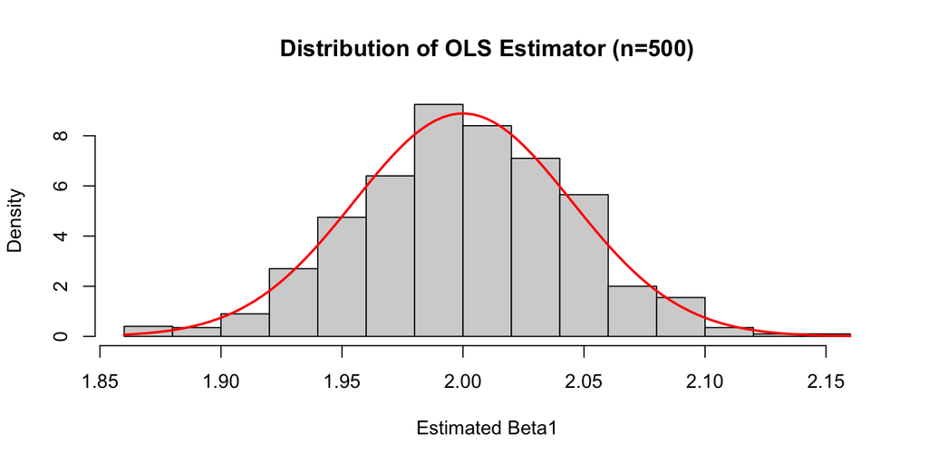

```r
# ヒストグラムと正規分布曲線の重ね書き
hist(beta1_estimates, probability = TRUE,
     main = "Distribution of OLS Estimator (n=500)",
     xlab = "Estimated Beta1")
curve(dnorm(x, mean = 2, sd = sd(beta1_estimates)),
      add = TRUE, col = "red", lwd = 2)
```

- 誤差項は一様分布だが、推定量の分布は綺麗な正規分布（ベル型）になっていることがわかる。

# 5-4 大規模標本でのラグランジュ乗数検定 (LM検定)

# LM検定 (Lagrange Multiplier Statistic)

- 複数の制約に関する検定として、F検定の代わりに使用されることがある。
- 特に、**制約付きモデル**（Restricted Model）のみを推定すればよいため、制約なしモデルの推定が困難な場合に便利である。
- 大規模標本において、LM統計量はカイ二乗分布 $\chi^2_q$ に従う（$q$ は制約の数）。

# LM検定の手順

1. 制約付きモデル（$H_0$ を課したモデル）を推定し、残差 $\tilde{u}$ を保存する。
2. 残差 $\tilde{u}$ を、制約なしモデルの**すべての**独立変数で回帰する（補助回帰）。
3. この補助回帰の決定係数 $R^2_{\tilde{u}}$ を取得する。
4. $LM = n \cdot R^2_{\tilde{u}}$ を計算する。
5. 自由度 $q$ のカイ二乗分布と比較してp値を求める。

# LM検定の例 (`crime1`)

- $H_0: \beta_{\text{avgsen}} = 0, \beta_{\text{tottime}} = 0$ （刑罰の厳しさは犯罪率に影響しない）

```r
data(crime1)
n <- nrow(crime1)
# 1. 制約付きモデル（刑罰変数なし）
model_r <- lm(narr86 ~ pcnv + ptime86 + qemp86,
              data = crime1)
u_tilde <- resid(model_r)

# 2. 補助回帰（残差をすべての変数で回帰）
# avgsen, tottime を追加
model_aux <- lm(u_tilde ~ pcnv + ptime86 + qemp86 +
                avgsen + tottime, data = crime1)
```

|  | Restricted Model | Auxiliary Regression |
| --- | --- | --- |
| (Intercept) | 0.712*** | -0.006 |
|  | (0.033) | (0.033) |
| pcnv | -0.150*** | -0.001 |
|  | (0.041) | (0.041) |
| ptime86 | -0.034*** | -0.005 |
|  | (0.009) | (0.009) |
| qemp86 | -0.104*** | 0.001 |
|  | (0.010) | (0.010) |
| avgsen |  | -0.007 |
|  |  | (0.012) |
| tottime |  | 0.012 |
|  |  | (0.010) |
| R2 | 0.041 | 0.001 |
| R2 Adj. | 0.040 | -0.000 |
| RMSE | 0.84 | 0.84 |

# LM検定の計算

```r
# 3 & 4. LM統計量の計算
lm_stat <- n * summary(model_aux)$r.squared
lm_stat
```

```
## [1] 4.070729
```

# LM検定の判定

```r
# 5. p値の計算 (自由度 q = 2)
p_value <- 1 - pchisq(lm_stat, df = 2)
p_value
```

```
## [1] 0.1306328
```

- p値が $0.05$ より大きければ、帰無仮説を棄却できない。
- F検定の結果と（漸近的に）類似するはずである。

# まとめ

# まとめ

- OLS推定量は、標本サイズが大きくなると真の値に確率収束する（**一致性**）。
- 誤差項が正規分布でなくても、標本サイズが十分に大きければ、OLS推定量は近似的に正規分布に従う（**漸近正規性**）。
- これにより、大規模標本では通常のt検定やF検定が妥当となる。
- LM検定は、大規模標本においてF検定の代替として利用できる（補助回帰を用いる）。